# AndrewBowen_DATA607_HW1

Andrew Bowen

2022-08-30

## Introduction

As a soccer fan, I’ve decided to use FiveThirtyEight’s [2022 Club Soccer Predictions](https://projects.fivethirtyeight.com/soccer-predictions/). I’ll be using their [club rankings data set](https://projects.fivethirtyeight.com/soccer-api/club/spi_global_rankings.csv) (also available on my [GitHub](https://raw.githubusercontent.com/andrewbowen19/cunyDATA607/main/data/spi_global_rankings.csv)) to see if the offenseive and defensive rating columns assigned by FiveThirtyEight are dependent on the league/name of a team. This dataset uses [ESPN’s Soccer Power Index](https://fivethirtyeight.com/methodology/how-our-club-soccer-predictions-work/) to assign teams a universal rating to normalize across different leagues/playing conditions (home vs away, etc.). This metric can be used to forecast the outcome of matches/seasons for a club. It also can be used to rank clubs from different leagues, where quality of play may differ.

```r
library('dplyr')
# Read in our dataset hosted on GitHub
url_path <- "https://raw.githubusercontent.com/andrewbowen19/cunyDATA607/main/data/spi_global_rankings.csv"
df = read.csv(url_path, header=TRUE)

head(df, 10)
```

```
##    rank prev_rank                name                   league  off  def   spi
## 1     1         1       Bayern Munich        German Bundesliga 3.38 0.44 93.17
## 2     2         2     Manchester City  Barclays Premier League 2.98 0.35 92.10
## 3     3         3 Paris Saint-Germain           French Ligue 1 3.07 0.51 90.35
## 4     4         4           Liverpool  Barclays Premier League 2.84 0.42 90.03
## 5     5         5         Real Madrid Spanish Primera Division 2.73 0.60 86.17
## 6     6         6           Barcelona Spanish Primera Division 2.48 0.48 85.82
## 7     7         7                Ajax         Dutch Eredivisie 2.88 0.74 85.19
## 8     8         8             Chelsea  Barclays Premier League 2.29 0.53 82.74
## 9     9         9      Internazionale            Italy Serie A 2.50 0.69 82.00
## 10   10        10   Tottenham Hotspur  Barclays Premier League 2.36 0.61 81.93
```

### Filtering our Dataset

I’m primarily a fan of the Italian Serie A. I’d like to filter our dataset based on the `league` column to only include the rows of teams that play in Serie A

```r
serie_a <- filter(df, league=="Italy Serie A") #| league=="Italy Serie B")

serie_a
```

```
##    rank prev_rank           name        league  off  def   spi
## 1     9         9 Internazionale Italy Serie A 2.50 0.69 82.00
## 2    17        17       AC Milan Italy Serie A 2.17 0.62 79.08
## 3    19        20         Napoli Italy Serie A 2.23 0.71 78.16
## 4    30        27        AS Roma Italy Serie A 1.92 0.68 73.91
## 5    32        29       Atalanta Italy Serie A 2.05 0.81 72.97
## 6    44        46       Juventus Italy Serie A 1.86 0.81 69.79
## 7    50        49          Lazio Italy Serie A 2.01 0.92 69.66
## 8    62        60     Fiorentina Italy Serie A 1.80 0.87 67.14
## 9    74        76         Torino Italy Serie A 1.66 0.88 64.04
## 10   89        94       Sassuolo Italy Serie A 1.92 1.24 60.84
## 11   93        91         Verona Italy Serie A 1.72 1.08 60.35
## 12  102       114        Udinese Italy Serie A 1.74 1.17 58.69
## 13  129       124        Bologna Italy Serie A 1.56 1.15 55.51
## 14  162       143      Sampdoria Italy Serie A 1.46 1.20 51.71
## 15  172       170          Lecce Italy Serie A 1.36 1.14 50.91
## 16  177       174         Empoli Italy Serie A 1.46 1.28 49.95
## 17  180       171          Monza Italy Serie A 1.42 1.27 49.39
## 18  183       178      Cremonese Italy Serie A 1.43 1.32 48.23
## 19  187       196    Salernitana Italy Serie A 1.45 1.35 48.10
## 20  196       185         Spezia Italy Serie A 1.43 1.38 46.93
```

### Dataset Measurements

The `off` and `def` columns represent the average number of goals scored/conceded against an average team on a neutral field. I’d like to calculate an average goal differential column (goals scored - goals conceded). I’d also like to see the difference in a club’s weekly ranking, given by our calculated `rank_diff` column (defined as $previous rank - new rank$)

```r
df <- df %>% mutate(rank_diff = prev_rank - rank)
df <- df %>% mutate(avg_diff = off - def)

head(df, 10)
```

```
##    rank prev_rank                name                   league  off  def   spi
## 1     1         1       Bayern Munich        German Bundesliga 3.38 0.44 93.17
## 2     2         2     Manchester City  Barclays Premier League 2.98 0.35 92.10
## 3     3         3 Paris Saint-Germain           French Ligue 1 3.07 0.51 90.35
## 4     4         4           Liverpool  Barclays Premier League 2.84 0.42 90.03
## 5     5         5         Real Madrid Spanish Primera Division 2.73 0.60 86.17
## 6     6         6           Barcelona Spanish Primera Division 2.48 0.48 85.82
## 7     7         7                Ajax         Dutch Eredivisie 2.88 0.74 85.19
## 8     8         8             Chelsea  Barclays Premier League 2.29 0.53 82.74
## 9     9         9      Internazionale            Italy Serie A 2.50 0.69 82.00
## 10   10        10   Tottenham Hotspur  Barclays Premier League 2.36 0.61 81.93
##    rank_diff avg_diff
## 1          0     2.94
## 2          0     2.63
## 3          0     2.56
## 4          0     2.42
## 5          0     2.13
## 6          0     2.00
## 7          0     2.14
## 8          0     1.76
## 9          0     1.81
## 10         0     1.75
```

### League Averages

Want to see the average SPI metrics of each league included in our dataset.

```r
league_avgs <- df %>% group_by(league)

league_avg_stats <- league_avgs %>% summarize(off=mean(off), def=mean(def), spi=mean(spi))
league_avg_stats
```

```
## # A tibble: 36 × 4
##    league                         off   def   spi
##    <chr>                        <dbl> <dbl> <dbl>
##  1 Argentina Primera Division   1.02  1.33   37.9
##  2 Australian A-League          0.832 2.13   20.2
##  3 Austrian T-Mobile Bundesliga 1.39  1.49   43.3
##  4 Barclays Premier League      2.00  0.790  71.5
##  5 Belgian Jupiler League       1.33  1.47   42.8
##  6 Brasileiro SÃ©rie A          1.31  1.06   51.5
##  7 Chinese Super League         0.584 2.34   13.5
##  8 Danish SAS-Ligaen            1.25  1.49   40.2
##  9 Dutch Eredivisie             1.65  1.30   53.0
## 10 English League Championship  1.23  1.31   43.8
## # … with 26 more rows
```

Sorting our league summary stats by SPI to get a sense of how the different leagues perform in terms of offensive, defensive, and SPI metrics. Sorting by SPI in order to see overall league performance according to this metric.

```r
league_avg_stats_sorted <- league_avg_stats %>% arrange(desc(spi))

league_avg_stats_sorted
```

```
## # A tibble: 36 × 4
##    league                                     off   def   spi
##    <chr>                                    <dbl> <dbl> <dbl>
##  1 Barclays Premier League                   2.00 0.790  71.5
##  2 German Bundesliga                         2.02 0.918  69.0
##  3 Spanish Primera Division                  1.80 0.794  68.3
##  4 Italy Serie A                             1.76 1.03   61.9
##  5 French Ligue 1                            1.74 1.01   61.7
##  6 UEFA Champions League                     1.72 1.26   56.1
##  7 Dutch Eredivisie                          1.65 1.30   53.0
##  8 Portuguese Liga                           1.45 1.13   52.5
##  9 Brasileiro SÃ©rie A                       1.31 1.06   51.5
## 10 Mexican Primera Division Torneo Apertura  1.34 1.28   47.1
## # … with 26 more rows
```

## Plots

Plotting the offensive and defensive ratings. Using the `ggplot2` library.

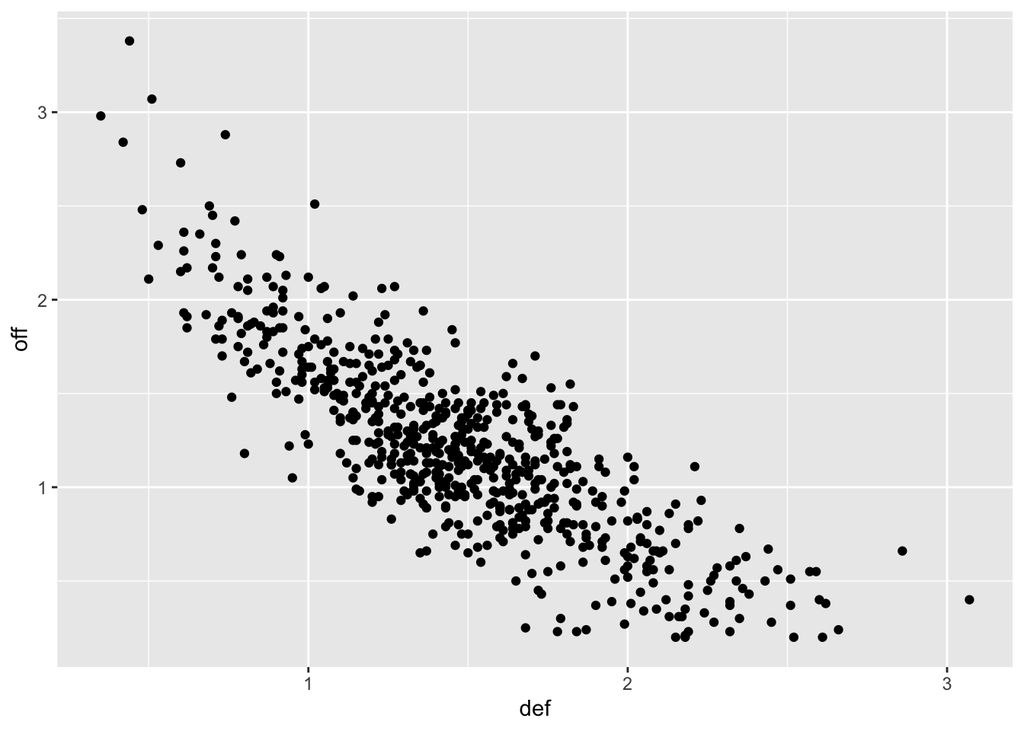

```r
library('ggplot2')

ggplot(df, aes(x=def, y=off)) + geom_point()
```

### Plotting by League

Want to make the same plot as above but colored by league. This could be a way for us to see if there are any trends between leagues in terms of club offensive and defensive performance. We only want the [Big 5 Leagues](https://www.statista.com/topics/5909/-big-five/) (Premier League, Bundesliga, Serie A, Ligue 1, La Liga), otherwise the chart becomes a bit busy.

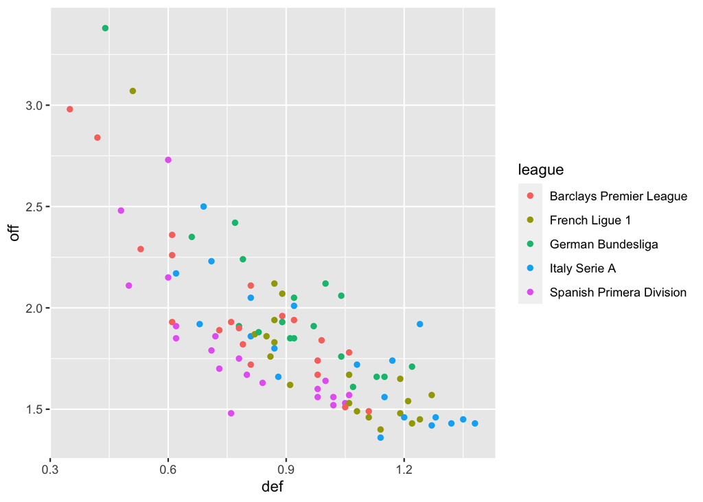

```r
# Filtering dataframe to the leagues we want
big5 <- filter(df, league=="Italy Serie A" |
                   league=="Barclays Premier League" |
                   league=="German Bundesliga" |
                   league=="Spanish Primera Division" |
                   league=="French Ligue 1"
                 )

ggplot(big5, aes(x=def, y=off, color=league)) + geom_point()
```

## Conclusion/Further Recommendations

One exercise that could be interesting to do with this dataset would be to see if there are any bias based on league in the SPI rankings. For instance, using European Tournaments, such as the UEFA Champions League or Europa League, could give insight into how leagues perform against each other. Discrepancies in how a league’s clubs perform on average would show that the SPI ranking favors certain leagues/clubs, even if their performance against outside competition does not reflect their ranking. This could also be used to compare how well the SPI metric predicts the outcomes of matches between two teams (in European competitions or otherwise). One other idea would be to try to classify a team’s league based on its offensive, defensive and SPI ratings.